# Lab2

Felix Baez-Santiago

9/8/2020

**Searching for the Best Chocolates We will be exploring what aspects of the chocolates may affect taste. Before setting off to the exploration, answer the following questions.**

```r
choco <- read.csv("https://raw.githubusercontent.com/xdaiISU/ds202materials/master/hwlabs/data/choco.csv")
str(choco)
```

```
## 'data.frame':    2312 obs. of  13 variables:
##  $ REF                 : int  2454 2458 2454 797 797 1015 1019 1011 1019 1011 ...
##  $ Company             : chr  "5150" "5150" "5150" "A. Morin" ...
##  $ Location            : chr  "U.S.A." "U.S.A." "U.S.A." "France" ...
##  $ Date                : int  2019 2019 2019 2012 2012 2013 2013 2013 2013 2013 ...
##  $ Bean_Origin         : chr  "Madagascar" "Dominican Republic" "Tanzania" "Peru" ...
##  $ Specific_Bean_Origin: chr  "Bejofo Estate, batch 1" "Zorzal, batch 1" "Kokoa Kamili, batch 1" "Peru" ...
##  $ Cocoa_Percent       : num  76 76 76 63 70 70 63 70 70 70 ...
##  $ Ingredients         : chr  "3- B,S,C" "3- B,S,C" "3- B,S,C" "4- B,S,C,L" ...
##  $ Characteristics1    : chr  "cocoa" "cocoa" "rich cocoa" "fruity" ...
##  $ Characteristics2    : chr  "blackberry" "vegetal" "fatty" "melon" ...
##  $ Characteristics3    : chr  "full body" "savory" "bready" "roasty" ...
##  $ Characteristics4    : chr  NA NA NA NA ...
##  $ Rating              : num  3.75 3.5 3.25 3.75 3.5 4 4 3.75 3.5 3.25 ...
```

1. How are the ratings distributed? Create both a histogram and a boxplot and describe them. Don’t forget to mention outliers, if there are any.

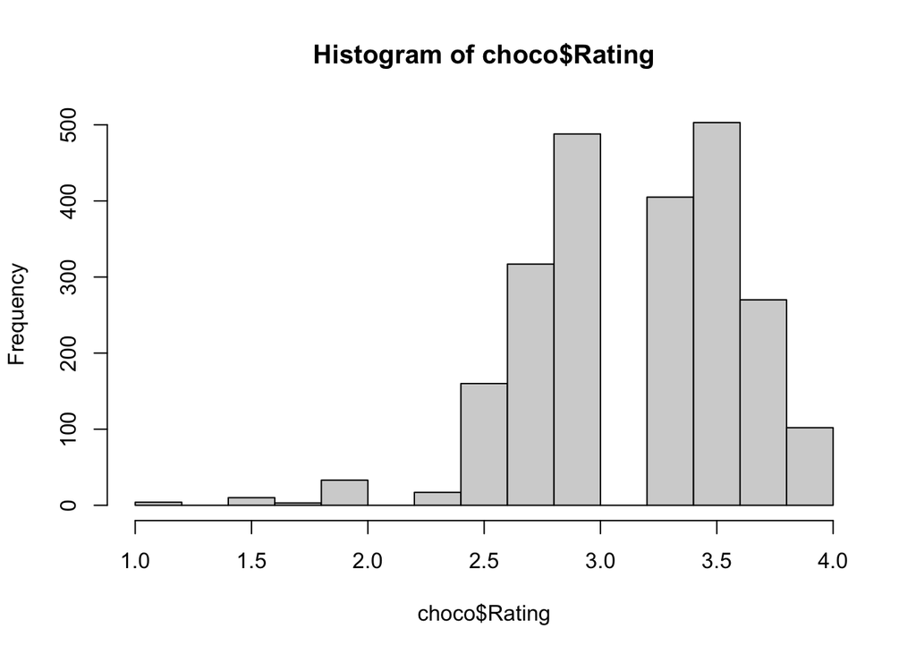

```r
hist(choco$Rating)
```

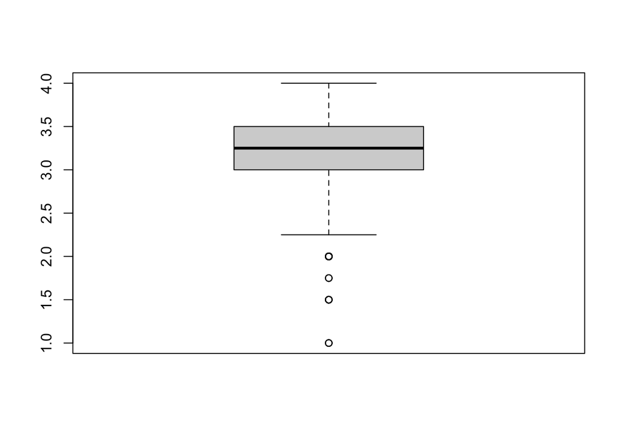

```r
boxplot(choco$Rating)
```

The histogram for Ratings is bimodal with multiple outliers. Most ratings seem to be centered around the number 3. The outliers are just a few low rated chocolates.

2. How does the number of ratings depend on the year? Draw a bar chart of the number of reports.

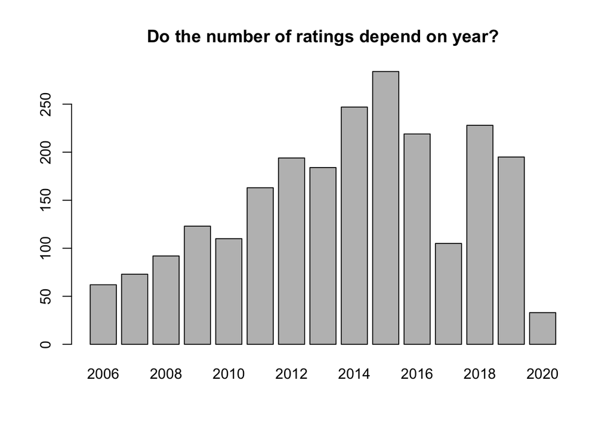

```r
counts <- table(choco$Date)
barplot(counts, main = "Do the number of ratings depend on year?")
```

3. Do ratings depend on the cacao percentage of a chocolate bar? Create both numerical and graphical summaries, and explain.

```r
cor(x = choco$Rating, y = choco$Cocoa_Percent) #numerical summary
```

```
## [1] -0.1510178
```

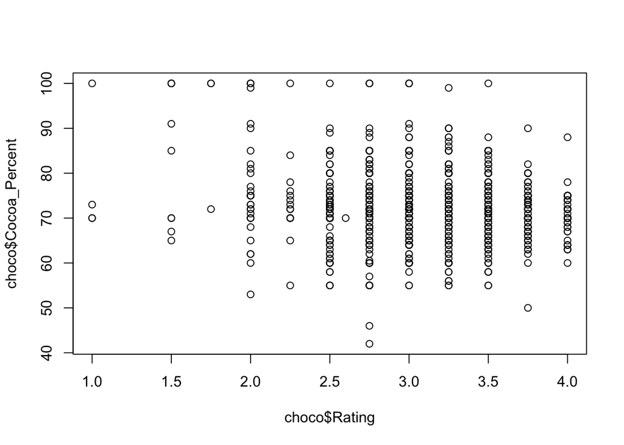

```r
plot(choco$Rating, choco$Cocoa_Percent) # graphical summary
```

The ratings don’t seem to depend on cocoa percentage. You can see many examples of this in the scatterplot that shows a wide range of values spread out between 50 and 90 percent of cocoa. The correlation coefficent is also very close to zero meaning that there is very high variability and barely any linear relationship between both variables.

4. How do different characteristics of the chocolate compare? To elaborate, which characteristics tend to be more favorable and which ones are not? Create both numerical and graphical summaries, and explain.

```r
chars <- unique(c(as.character(choco$Characteristics1), as.character(choco$Characteristics2), as.character(choco$Characteristics3), as.character(choco$Characteristics4)))
chars <- chars[!is.na(chars) & chars != ""]
chars
```

```
##   [1] "cocoa"                          "rich cocoa"
##   [3] "fruity"                         "vegetal"
##   [5] "oily"                           "sweet"
##   [7] "sandy"                          "mild tobacco"
##   [9] "mild fruit"                     "green"
##  [11] "sticky"                         "brief fruit note"
##  [13] "burnt rubber"                   "delicate"
##  [15] "astringent"                     "sliglty dry"
##  [17] "nutty"                          "harsh"
##  [19] "mild profile"                   "grainy texture"
##  [21] "roasty"                         "burnt wood"
##  [23] "alluring aroma"                 "yellow fruit"
##  [25] "intense"                        "hot cocoa"
##  [27] "herbal"                         "orange"
##  [29] "spicy"                          "basic"
```

[output cut: 410 more lines]

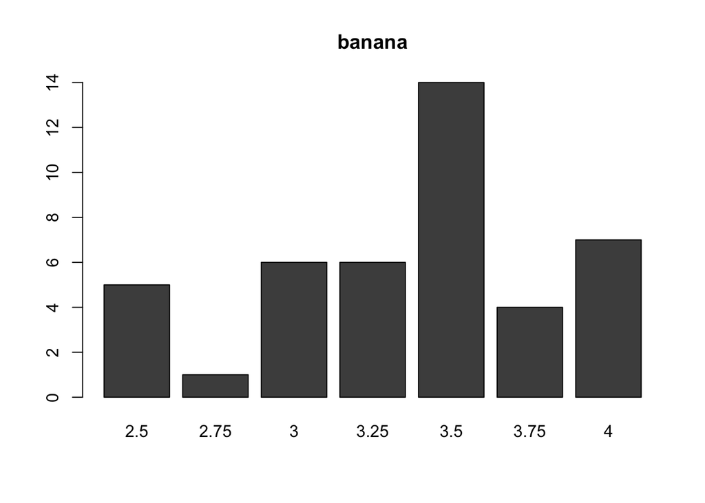

```r
charFunction <- function(targetChar){
  choco[,targetChar] <- !is.na(choco$Characteristics1) & choco$Characteristics1 == targetChar | !is.na(choco$Characteristics2) & choco$Characteristics2 == targetChar | !is.na(choco$Characteristics3) & choco$Characteristics3 == targetChar | !is.na(choco$Characteristics4) & choco$Characteristics4 == targetChar
  summary(choco[choco[,targetChar], "Rating"])
  barplot(table(choco[choco[,targetChar], targetChar], choco[choco[,targetChar], "Rating"]),  main = targetChar)
}
charFunction("banana")
```

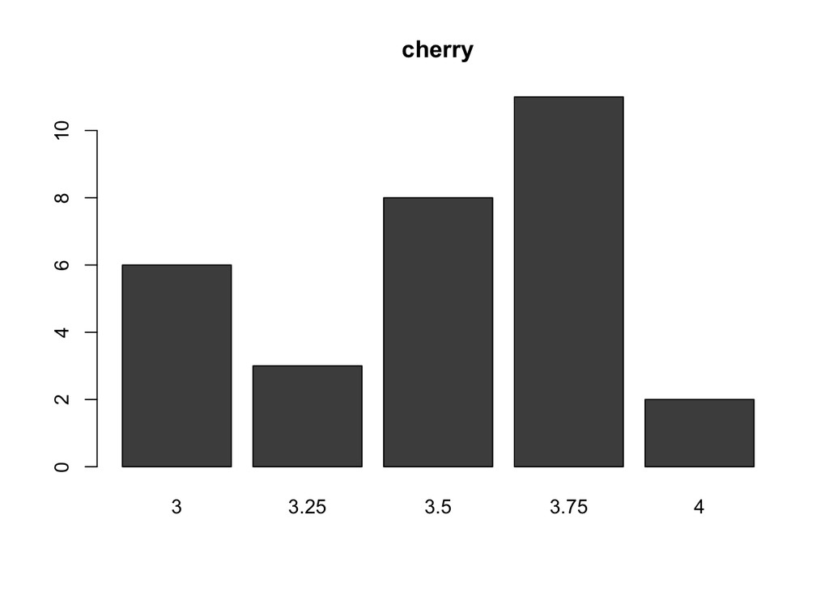

```r
#The flavor banana seems to be generally favorable with 14 bars having a 3.5 rating.
charFunction("cherry")
```